# Assignment_5

Chen, Yen-Ting

2021/10/26

# Assignment 5

```r
pacman::p_load(dplyr, ggplot2, tidyr)
```

COM(P)ADRE is an online repository containing matrix population models on hundreds of plants, animals, algae, fungi, bacteria, and viruses around the world. In this assignment, you will be analyzing the population matrix of a species (of your choice) using the data provided on the website and making some interpretations of your results. Please follow the instructions below to select a suitable species for the assignment questions:

1. Visit the database at https://compadre-db.org/ExploreDatabase.
2. Pick a species you like, either by clicking on the entries below or searching by the taxonomy of organisms on the upper right.
3. This species should meet the following criteria:
- It has data on two or more populations.
- These populations should be “distinct” enough for comparisons (e.g., populations at different latitudes, populations in different habitat types, populations inhabiting different soil types, etc.).
- These populations should have population matrix data over the same time period. If there are multiple time periods, please use the overall period data for comparisons across sites.
- If some of the criteria are not met, you may want to look for another species.
4. After you get an ideal species, you can now start working on your questions. (A worked example is provided in the following for your reference.)

## 1. Briefly introduce the life stages of the species you chose. (1 pt)

Here I choose the species *Acipenser fulvescens* (commonly known as lake sturgeon). Five age-specific stages of these models are age 0, early juvenile, late juvenile, early adult, and late adult. Following the authors synthesis, age 0 is the hatched individuals that before age 1; early and late juvenile stages are the first and second half period between age 1 and the mean mature age of 24 years; the early and late adult stages are the first and the second half of the adult period. Do note that ages of lake sturgeons were estimated from individual sizes by using von Bertalanffy growth model (VBGM); the maximum age of adult period were defined as the 95% $L_\inf$ where $L_\inf$ is the site-specific asymptotic length.

## 2. Create Leslie matrices for the populations and derive their asymptotic growth rates λ’s (please include your R code). (5 pts)

```r
# Western Hudson bay
col1 <- c(0, 0.00187, 0, 0, 0)
col2 <- c(0, 0.262353, 0.02385, 0, 0)
col3 <- c(537.7776, 0, 0.659134, 0.065913, 0)
col4 <- c(7684.603, 0, 0, 0.864969, 0.050881)
col5 <- c(10629.76, 0, 0, 0, 0.861976)

col_name <- c("Age_0", "Early_Juvenile", "Late_Juvenile", "Early_Adult", "Late_Adult")


DU1 <- cbind(col1, col2, col3, col4, col5) %>% as.matrix
colnames(DU1) <- col_name
```

Table 1. The matrix population model of DU1.

```r
DU1 %>% knitr::kable()
```

| Age_0 | Early_Juvenile | Late_Juvenile | Early_Adult | Late_Adult |
| --- | --- | --- | --- | --- |
| 0.00000 | 0.000000 | 537.777600 | 7684.603000 | 10629.760000 |
| 0.00187 | 0.262353 | 0.000000 | 0.000000 | 0.000000 |
| 0.00000 | 0.023850 | 0.659134 | 0.000000 | 0.000000 |
| 0.00000 | 0.000000 | 0.065913 | 0.864969 | 0.000000 |
| 0.00000 | 0.000000 | 0.000000 | 0.050881 | 0.861976 |

```r
# Lake Erie-Lake Huron
col1 <- c(0, 0.0009, 0, 0, 0)
col2 <- c(0, 0.258099, 0.023464, 0, 0)
col3 <- c(1163.077, 0, 0.648447, 0.064845, 0)
col4 <- c(17028.83, 0, 0, 0.880095, 0.044005)
col5 <- c(24800.67, 0, 0, 0, 0.877895)

DU8A <- cbind(col1, col2, col3, col4, col5) %>% as.matrix
colnames(DU8A) <- col_name
```

Table 2. The matrix population of DU8A

```r
DU8A %>% knitr::kable()
```

| Age_0 | Early_Juvenile | Late_Juvenile | Early_Adult | Late_Adult |
| --- | --- | --- | --- | --- |
| 0e+00 | 0.000000 | 1163.077000 | 17028.830000 | 24800.670000 |
| 9e-04 | 0.258099 | 0.000000 | 0.000000 | 0.000000 |
| 0e+00 | 0.023464 | 0.648447 | 0.000000 | 0.000000 |
| 0e+00 | 0.000000 | 0.064845 | 0.880095 | 0.000000 |
| 0e+00 | 0.000000 | 0.000000 | 0.044005 | 0.877895 |

Table 3. The population growth rate ($\lambda$) of the two sites.

```r
data.frame(site = c("DU1", "DU8A"),
           lambda = c(max(Re(eigen(DU1)$values)), max(Re(eigen(DU8A)$values)))) %>% knitr::kable()
```

| site | lambda |
| --- | --- |
| DU1 | 1.006824 |
| DU8A | 1.014131 |

```r
# eigen(DU1)$vectors[,1] %>% Re
# eigen(DU8A)$vectors[,1] %>% Re
```

```r
time <- 50
n0 <- 10

nu_DU1<- data.frame(time = 1:time,
                    Age_0 = n0,
                    Early_Juvenile = n0,
                    Late_Juvenile = n0,
                    Early_Adult = n0,
                    Late_Adult = n0)

for (i in 2:time){
  nu_DU1[i, -1] <- DU1 %*% t(nu_DU1[i-1, -1])
}

nu_DU8A<- data.frame(time = 1:time,
                     Age_0 = n0,
                     Early_Juvenile = n0,
                     Late_Juvenile = n0,
                     Early_Adult = n0,
                     Late_Adult = n0)

for (i in 2:time){
  nu_DU8A[i, -1] <- DU8A %*% t(nu_DU8A[i-1, -1])
}

nu_DU1$Location <- "DU1"
nu_DU8A$Location <- "DU8A"

col_pi <- c("Age_0", "Early_Juvenile", "Late_Juvenile", "Early_Adult", "Late_Adult")

df <-
  rbind(nu_DU1, nu_DU8A) %>%
  pivot_longer(cols = all_of(col_pi), names_to = "Stage", values_to = "N")

df$Stage <- factor(df$Stage, col_pi)
```

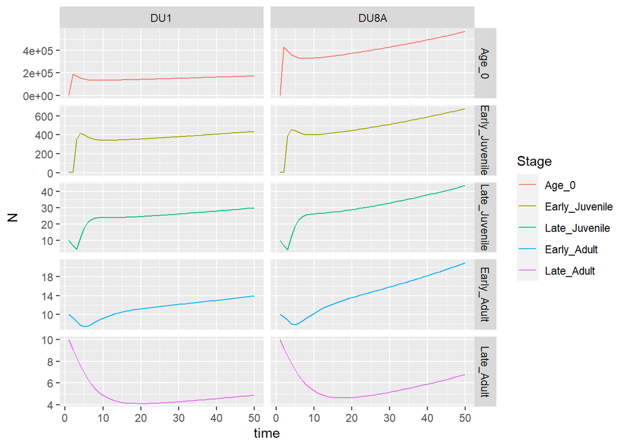

```r
ggplot(df, aes(x =time, y = N, color = Stage)) +
  geom_path() +
  facet_grid(Stage ~ Location, scales = "free_y")
```

Figure 2. The demographic structure of the lake sturgeon population with the initial population size defined as 10 through all stages.

## 3. Compare the λ’s of these populations and provide some interpretations/explanations of your findings. You can think about the biology of that species and the abiotic/biotic characteristics associated with each population. (4 pts)

In general, the two populations have similar growth patterns. They not only have positive growth rates but also shares similar demographic structures. The only notable difference is that the expansion rate of DU8A across all stages are higher than DU1 and such difference can be caused by the difference in overharvesting pressure of the two locations.

Main reference:

Luis A. Velez-Expina & Marten A. Koops. (2009) Recovery Potential Assessment for Lake Sturgeon in Canadian Designatable Units, North American Journal of Fisheries Management, 29:4, 1065-1090, DOI:10.1577/M08-034.1